# **Ananya Garg(21BCE0518)**

Assignment 2 - 8th september

1.Take car crashes dataset from seaborn library

2.load the dataset

3.Perfrom Data Visualization

4.Inference is must for each and every graph

5.Submit it by wednesday in html format

--Univariate-only one variable at a time-histograms,bar charts,pie charts,boxplots-categorical or numerical

--Bivariate--two variables categorical or numerical

numerical vs numerical -- scatterplot

numerical vs categorical -- ANOVA(analysis of variance)

categorical vs categorical -- chi squarred error test

--Multi variate - many variables

clustering analysis

Principal component analysis PCA

Multi correspondence analysis

```python
import numpy as np
import pandas as pd
import matplotlib.pyplot as plt
import seaborn as sns
```

```python
print(sns.get_dataset_names())
```

```
['anagrams', 'anscombe', 'attention', 'brain_networks', 'car_crashes', 'diamonds', 'dots', 'dowjones', 'exercise', 'flights', 'fmri', 'geyser', 'glue', 'healthexp', 'iris', 'mpg', 'penguins', 'planets', 'seaice', 'taxis', 'tips', 'titanic']
```

```python
df=sns.load_dataset('car_crashes')
df
```

|  | total | speeding | alcohol | not_distracted | no_previous | ins_premium | ins_losses | abbrev |
| --- | --- | --- | --- | --- | --- | --- | --- | --- |
| 0 | 18.8 | 7.332 | 5.640 | 18.048 | 15.040 | 784.55 | 145.08 | AL |
| 1 | 18.1 | 7.421 | 4.525 | 16.290 | 17.014 | 1053.48 | 133.93 | AK |
| 2 | 18.6 | 6.510 | 5.208 | 15.624 | 17.856 | 899.47 | 110.35 | AZ |
| 3 | 22.4 | 4.032 | 5.824 | 21.056 | 21.280 | 827.34 | 142.39 | AR |
| 4 | 12.0 | 4.200 | 3.360 | 10.920 | 10.680 | 878.41 | 165.63 | CA |
| 5 | 13.6 | 5.032 | 3.808 | 10.744 | 12.920 | 835.50 | 139.91 | CO |
| 6 | 10.8 | 4.968 | 3.888 | 9.396 | 8.856 | 1068.73 | 167.02 | CT |
| 7 | 16.2 | 6.156 | 4.860 | 14.094 | 16.038 | 1137.87 | 151.48 | DE |
| 8 | 5.9 | 2.006 | 1.593 | 5.900 | 5.900 | 1273.89 | 136.05 | DC |
| 9 | 17.9 | 3.759 | 5.191 | 16.468 | 16.826 | 1160.13 | 144.18 | FL |
| 10 | 15.6 | 2.964 | 3.900 | 14.820 | 14.508 | 913.15 | 142.80 | GA |
| 11 | 17.5 | 9.450 | 7.175 | 14.350 | 15.225 | 861.18 | 120.92 | HI |
| 12 | 15.3 | 5.508 | 4.437 | 13.005 | 14.994 | 641.96 | 82.75 | ID |
| 13 | 12.8 | 4.608 | 4.352 | 12.032 | 12.288 | 803.11 | 139.15 | IL |
| 14 | 14.5 | 3.625 | 4.205 | 13.775 | 13.775 | 710.46 | 108.92 | IN |
| 15 | 15.7 | 2.669 | 3.925 | 15.229 | 13.659 | 649.06 | 114.47 | IA |
| 16 | 17.8 | 4.806 | 4.272 | 13.706 | 15.130 | 780.45 | 133.80 | KS |
| 17 | 21.4 | 4.066 | 4.922 | 16.692 | 16.264 | 872.51 | 137.13 | KY |
| 18 | 20.5 | 7.175 | 6.765 | 14.965 | 20.090 | 1281.55 | 194.78 | LA |
| 19 | 15.1 | 5.738 | 4.530 | 13.137 | 12.684 | 661.88 | 96.57 | ME |
| 20 | 12.5 | 4.250 | 4.000 | 8.875 | 12.375 | 1048.78 | 192.70 | MD |
| 21 | 8.2 | 1.886 | 2.870 | 7.134 | 6.560 | 1011.14 | 135.63 | MA |
| 22 | 14.1 | 3.384 | 3.948 | 13.395 | 10.857 | 1110.61 | 152.26 | MI |
| 23 | 9.6 | 2.208 | 2.784 | 8.448 | 8.448 | 777.18 | 133.35 | MN |
| 24 | 17.6 | 2.640 | 5.456 | 1.760 | 17.600 | 896.07 | 155.77 | MS |
| 25 | 16.1 | 6.923 | 5.474 | 14.812 | 13.524 | 790.32 | 144.45 | MO |
| 26 | 21.4 | 8.346 | 9.416 | 17.976 | 18.190 | 816.21 | 85.15 | MT |
| 27 | 14.9 | 1.937 | 5.215 | 13.857 | 13.410 | 732.28 | 114.82 | NE |
| 28 | 14.7 | 5.439 | 4.704 | 13.965 | 14.553 | 1029.87 | 138.71 | NV |
| 29 | 11.6 | 4.060 | 3.480 | 10.092 | 9.628 | 746.54 | 120.21 | NH |
| 30 | 11.2 | 1.792 | 3.136 | 9.632 | 8.736 | 1301.52 | 159.85 | NJ |
| 31 | 18.4 | 3.496 | 4.968 | 12.328 | 18.032 | 869.85 | 120.75 | NM |
| 32 | 12.3 | 3.936 | 3.567 | 10.824 | 9.840 | 1234.31 | 150.01 | NY |
| 33 | 16.8 | 6.552 | 5.208 | 15.792 | 13.608 | 708.24 | 127.82 | NC |
| 34 | 23.9 | 5.497 | 10.038 | 23.661 | 20.554 | 688.75 | 109.72 | ND |
| 35 | 14.1 | 3.948 | 4.794 | 13.959 | 11.562 | 697.73 | 133.52 | OH |
| 36 | 19.9 | 6.368 | 5.771 | 18.308 | 18.706 | 881.51 | 178.86 | OK |
| 37 | 12.8 | 4.224 | 3.328 | 8.576 | 11.520 | 804.71 | 104.61 | OR |
| 38 | 18.2 | 9.100 | 5.642 | 17.472 | 16.016 | 905.99 | 153.86 | PA |
| 39 | 11.1 | 3.774 | 4.218 | 10.212 | 8.769 | 1148.99 | 148.58 | RI |
| 40 | 23.9 | 9.082 | 9.799 | 22.944 | 19.359 | 858.97 | 116.29 | SC |
| 41 | 19.4 | 6.014 | 6.402 | 19.012 | 16.684 | 669.31 | 96.87 | SD |
| 42 | 19.5 | 4.095 | 5.655 | 15.990 | 15.795 | 767.91 | 155.57 | TN |
| 43 | 19.4 | 7.760 | 7.372 | 17.654 | 16.878 | 1004.75 | 156.83 | TX |
| 44 | 11.3 | 4.859 | 1.808 | 9.944 | 10.848 | 809.38 | 109.48 | UT |
| 45 | 13.6 | 4.080 | 4.080 | 13.056 | 12.920 | 716.20 | 109.61 | VT |
| 46 | 12.7 | 2.413 | 3.429 | 11.049 | 11.176 | 768.95 | 153.72 | VA |
| 47 | 10.6 | 4.452 | 3.498 | 8.692 | 9.116 | 890.03 | 111.62 | WA |
| 48 | 23.8 | 8.092 | 6.664 | 23.086 | 20.706 | 992.61 | 152.56 | WV |
| 49 | 13.8 | 4.968 | 4.554 | 5.382 | 11.592 | 670.31 | 106.62 | WI |
| 50 | 17.4 | 7.308 | 5.568 | 14.094 | 15.660 | 791.14 | 122.04 | WY |

```python
df.info()
```

```
<class 'pandas.core.frame.DataFrame'>
RangeIndex: 51 entries, 0 to 50
Data columns (total 8 columns):
 #   Column          Non-Null Count  Dtype
---  ------          --------------  -----
 0   total           51 non-null     float64
 1   speeding        51 non-null     float64
 2   alcohol         51 non-null     float64
 3   not_distracted  51 non-null     float64
 4   no_previous     51 non-null     float64
 5   ins_premium     51 non-null     float64
 6   ins_losses      51 non-null     float64
 7   abbrev          51 non-null     object
dtypes: float64(7), object(1)
memory usage: 3.3+ KB
```

```python
df.head()
```

|  | total | speeding | alcohol | not_distracted | no_previous | ins_premium | ins_losses | abbrev |
| --- | --- | --- | --- | --- | --- | --- | --- | --- |
| 0 | 18.8 | 7.332 | 5.640 | 18.048 | 15.040 | 784.55 | 145.08 | AL |
| 1 | 18.1 | 7.421 | 4.525 | 16.290 | 17.014 | 1053.48 | 133.93 | AK |
| 2 | 18.6 | 6.510 | 5.208 | 15.624 | 17.856 | 899.47 | 110.35 | AZ |
| 3 | 22.4 | 4.032 | 5.824 | 21.056 | 21.280 | 827.34 | 142.39 | AR |
| 4 | 12.0 | 4.200 | 3.360 | 10.920 | 10.680 | 878.41 | 165.63 | CA |

```python
df.describe()
```

|  | total | speeding | alcohol | not_distracted | no_previous | ins_premium | ins_losses |
| --- | --- | --- | --- | --- | --- | --- | --- |
| count | 51.000000 | 51.000000 | 51.000000 | 51.000000 | 51.000000 | 51.000000 | 51.000000 |
| mean | 15.790196 | 4.998196 | 4.886784 | 13.573176 | 14.004882 | 886.957647 | 134.493137 |
| std | 4.122002 | 2.017747 | 1.729133 | 4.508977 | 3.764672 | 178.296285 | 24.835922 |
| min | 5.900000 | 1.792000 | 1.593000 | 1.760000 | 5.900000 | 641.960000 | 82.750000 |
| 25% | 12.750000 | 3.766500 | 3.894000 | 10.478000 | 11.348000 | 768.430000 | 114.645000 |
| 50% | 15.600000 | 4.608000 | 4.554000 | 13.857000 | 13.775000 | 858.970000 | 136.050000 |
| 75% | 18.500000 | 6.439000 | 5.604000 | 16.140000 | 16.755000 | 1007.945000 | 151.870000 |
| max | 23.900000 | 9.450000 | 10.038000 | 23.661000 | 21.280000 | 1301.520000 | 194.780000 |

```python
x = df["total"].values
y = df["alcohol"].values
z = df["speeding"].values
```

```python
x
```

```
array([18.8, 18.1, 18.6, 22.4, 12. , 13.6, 10.8, 16.2,  5.9, 17.9, 15.6,
       17.5, 15.3, 12.8, 14.5, 15.7, 17.8, 21.4, 20.5, 15.1, 12.5,  8.2,
       14.1,  9.6, 17.6, 16.1, 21.4, 14.9, 14.7, 11.6, 11.2, 18.4, 12.3,
       16.8, 23.9, 14.1, 19.9, 12.8, 18.2, 11.1, 23.9, 19.4, 19.5, 19.4,
       11.3, 13.6, 12.7, 10.6, 23.8, 13.8, 17.4])
```

```python
y
```

```
array([ 5.64 ,  4.525,  5.208,  5.824,  3.36 ,  3.808,  3.888,  4.86 ,
        1.593,  5.191,  3.9  ,  7.175,  4.437,  4.352,  4.205,  3.925,
        4.272,  4.922,  6.765,  4.53 ,  4.   ,  2.87 ,  3.948,  2.784,
        5.456,  5.474,  9.416,  5.215,  4.704,  3.48 ,  3.136,  4.968,
        3.567,  5.208, 10.038,  4.794,  5.771,  3.328,  5.642,  4.218,
        9.799,  6.402,  5.655,  7.372,  1.808,  4.08 ,  3.429,  3.498,
        6.664,  4.554,  5.568])
```

```python
z
```

```
array([7.332, 7.421, 6.51 , 4.032, 4.2  , 5.032, 4.968, 6.156, 2.006,
       3.759, 2.964, 9.45 , 5.508, 4.608, 3.625, 2.669, 4.806, 4.066,
       7.175, 5.738, 4.25 , 1.886, 3.384, 2.208, 2.64 , 6.923, 8.346,
       1.937, 5.439, 4.06 , 1.792, 3.496, 3.936, 6.552, 5.497, 3.948,
       6.368, 4.224, 9.1  , 3.774, 9.082, 6.014, 4.095, 7.76 , 4.859,
       4.08 , 2.413, 4.452, 8.092, 4.968, 7.308])
```

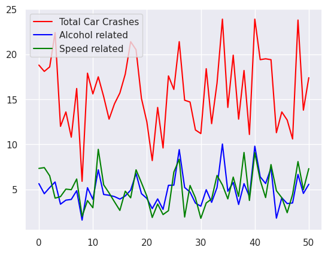

```python
plt.figure()
plt.plot(x, label='Total Car Crashes', color='red')
plt.plot(y, label='Alcohol related', color='blue')
plt.plot(z, label='Speed related', color='green')
plt.legend()
sns.set()
plt.show()
```

**Inference - From the plot we can see how the data varies with increasing parameters.**

# Scatter plot

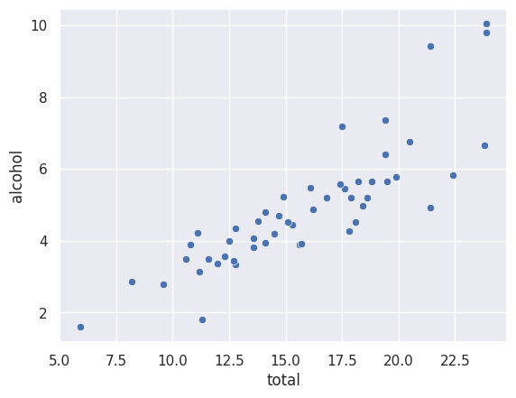

```python
sns.scatterplot(x="total",y="alcohol",data=df)
```

**Inference - From the plot we can say that the total number of car crashes increases as the alcohol parameter increases.**

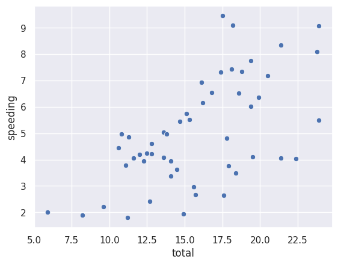

```python
sns.scatterplot(x="total",y="speeding",data=df)
```

**Inference - From the plot we can say that the total number of car crashes increases as the speeding parameter increases, although some carsh crahes occurs even at less speed**

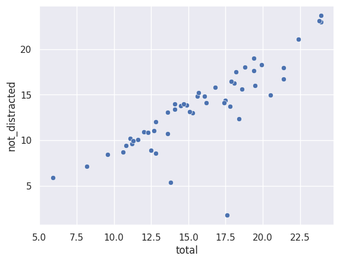

```python
sns.scatterplot(x="total",y="not_distracted",data=df)
```

**Inference - From the plot we can say that the total number of car crashes increases as the non_distracted parameter increases**

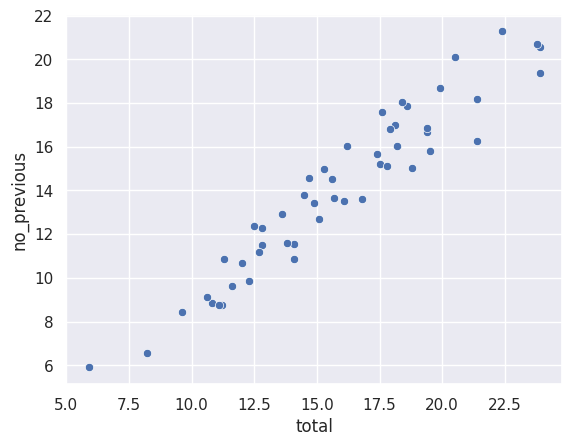

```python
sns.scatterplot(x="total",y="no_previous",data=df)
```

**Inference - From the plot we can say that the total number of car crashes increases as the no_previous parameter increases**

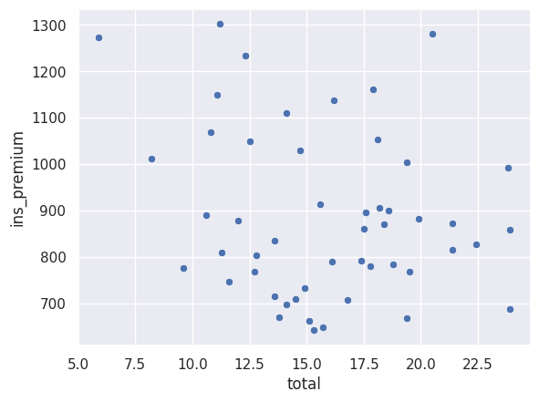

```python
sns.scatterplot(x="total",y="ins_premium",data=df)
```

**Inference - There is a wide spread of points along the x-axis and y-axis which indicates higher variability. Total car crashes between range 12.5 to 20 are more.**

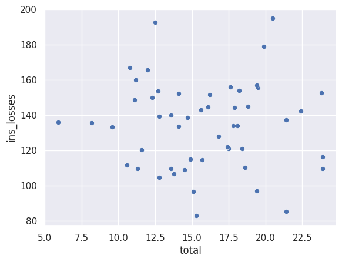

```python
sns.scatterplot(x="total",y="ins_losses",data=df)
```

**Inference - There is a wide spread of points along the x-axis and y-axis which indicates higher variability.**

# Line plot

-Line plots provide an overall visual representation of how the data behaves

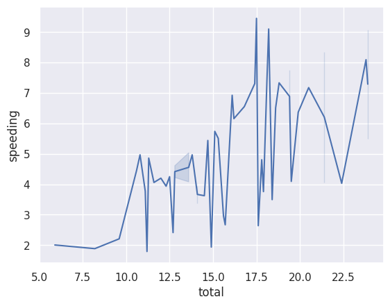

```python
sns.lineplot(x="total",y="speeding",data=df)
```

**Inference - From the plot we can see that there is a grdual increase in the no. of total car crashes ins some areas and a grdual decrease in some areas with the increase=ing speed. The data is relatively stable in some part of the range 12.5-15.**

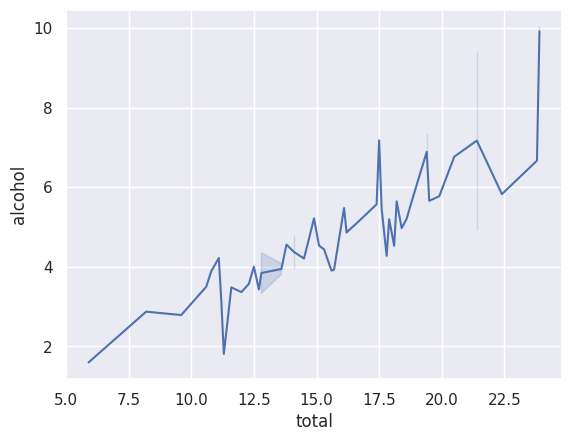

```python
sns.lineplot(x="total",y="alcohol",data=df)
```

**Inference - From the plot we can see that there is a grdual increase in the no. of total car crashes as the alcohol parameter increases.**

# Distribution plot

-It is used to explore and understand the distribution of a single variable. It provides insights into the shape, spread, and central tendencies of the data.

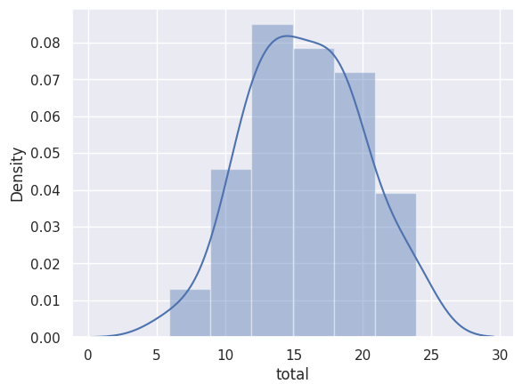

```python
sns.distplot(df["total"])
```

**Inference - From the plot we can see that the data follows a normal distribution (bell-shaped curve).The peak or center of the curve corresponds to the mean of the data. x-axis shows the range of values in the data, y-axis represents the probability density.**

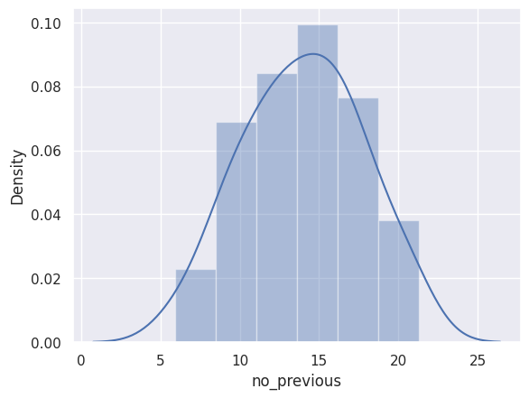

```python
sns.distplot(df["no_previous"])
```

**Inference - From the plot we can see that the data follows a normal distribution.It is Unimodal distribution i.e it has one peak.**

# Relationship plot

-It is used to explore relationships between variables in a dataset.

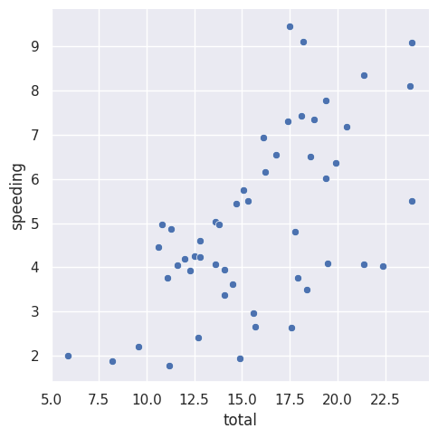

```python
sns.relplot(x="total",y="speeding",data=df)
```

**Inference - From the plot we can see that the sns.relplot function is used to create a scatter plot.Each data point in the plot represents a combination of "total" and "speeding" values.There is positive correlation between total and speeding parameters.**

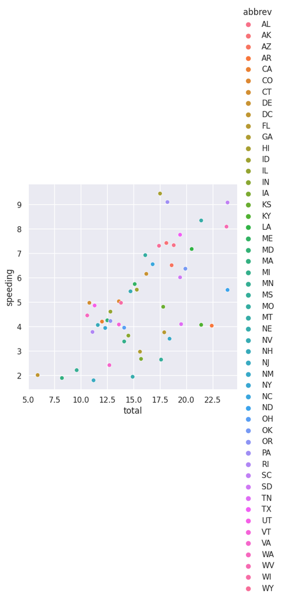

```python
sns.relplot(x="total",y="speeding",data=df,hue="abbrev")
```

**Inference - From the plot we can see that hue is a parameter that is used to colorize or categorically differentiate data points in a plot based on a third categorical variable-"abbrev". it divides the data into groups and assigns a different color to each group.**

# Bar plot

-It is a useful tool for summarizing and comparing numeric values across different categories, making it easier to identify patterns, differences, and trends within your data

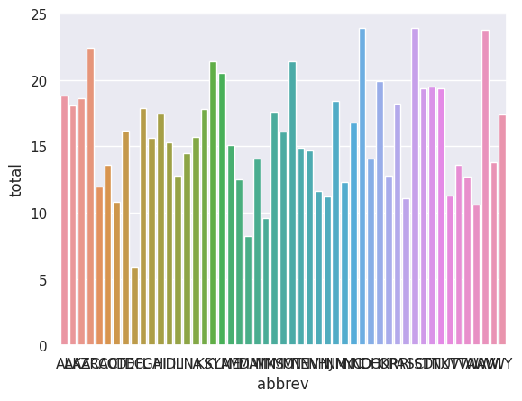

```python
sns.barplot(data=df,x="abbrev",y="total")
```

```python
max_total = df["total"].max()
max_value = df[df["total"] == max_total]["abbrev"].values[0]
max_value
```

```
'ND'
```

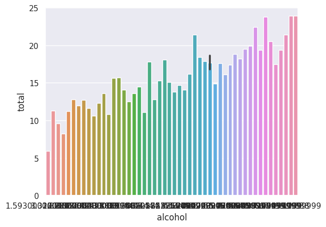

```python
sns.barplot(data=df,x='alcohol', y='total')
```

```python
max_total = df["total"].max()
max_value = df[df["total"] == max_total]["alcohol"].values[0]
max_value
```

```
10.038
```

**Inference - From the plot we can see that alcohol value "10.038" has the highest "total"(total car crashes) value. Each bar represents a unique category from the "alcohol" column, and the height of each bar corresponds to the value of the "total" column for that category**

# Count plot

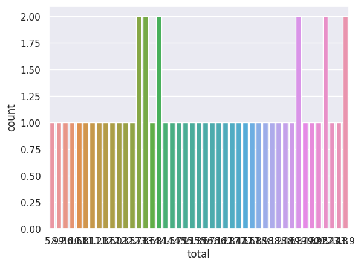

```python
sns.countplot(x="total",data=df)
```

**Inference - From the plot we can see that the plot shows the frequency or count of each category within a categorical variable.**

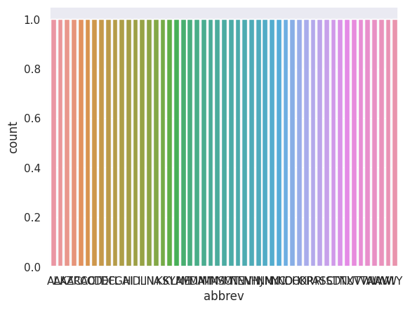

```python
sns.countplot(x="abbrev",data=df)
```

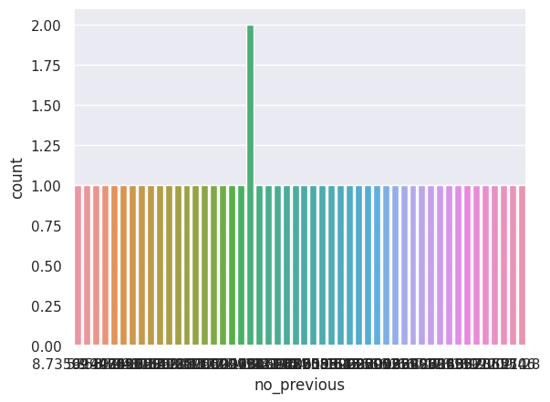

```python
sns.countplot(x="no_previous",data=df)
```

# Joint plot

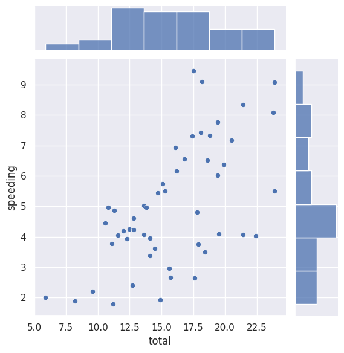

```python
sns.jointplot(x="total",y="speeding",data=df)
```

**Inference - From the plot we can see that the central part of the joint plot is a scatter plot. Each data point represents a combination of "total" on the x-axis and "speeding" on the y-axis.The marginal histograms on the top and right sides of the joint plot show the distribution of "total" and "speeding" individually.**

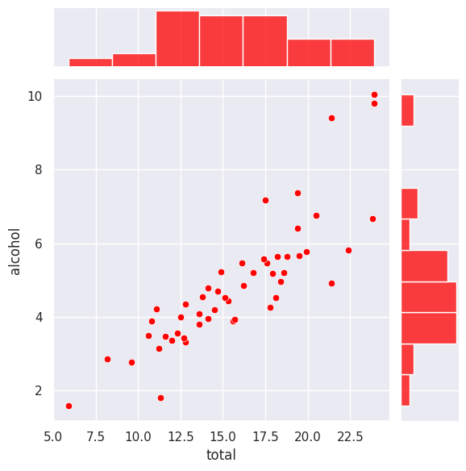

```python
sns.jointplot(x="total",y="alcohol",data=df,color="red")
```

**Inference - From the plot we can see that there is a positive correlation between the two parameter i.e the total no. car crashes increases with increase in alcohol parameter.The color parameter is used to enhance readability and presentation of the plot.**

# Box plot

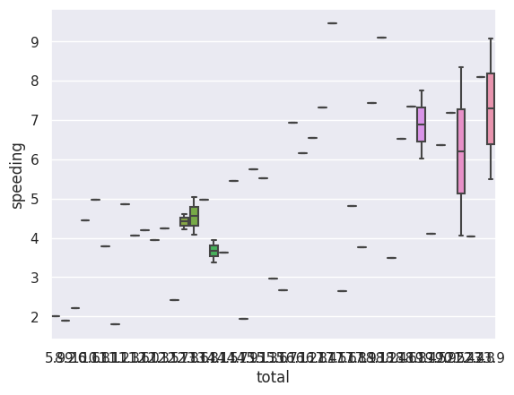

```python
sns.boxplot(x="total",y="speeding",data=df)
```

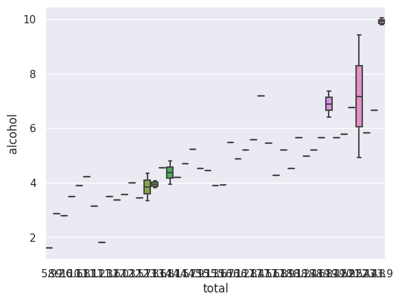

```python
sns.boxplot(x="total",y="alcohol",data=df)
```

**Inference - From the plot we can see that the central box of the plot represents the interquartile range (IQR), where the bottom and top edges of the box represent the first quartile (Q1) and the third quartile (Q3), respectively. The horizontal line inside the box represents the median (Q2).**

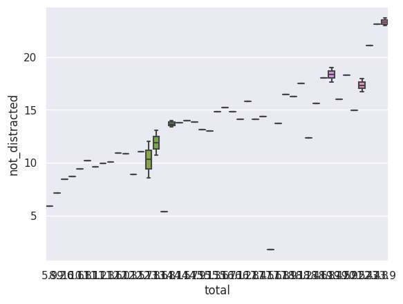

```python
sns.boxplot(x="total",y="not_distracted",data=df)
```

# Correlation

```python
# >0.5 is highly correlated
# <0.5 is less correlated
corr=df.corr()
corr
```

|  | total | speeding | alcohol | not_distracted | no_previous | ins_premium | ins_losses |
| --- | --- | --- | --- | --- | --- | --- | --- |
| total | 1.000000 | 0.611548 | 0.852613 | 0.827560 | 0.956179 | -0.199702 | -0.036011 |
| speeding | 0.611548 | 1.000000 | 0.669719 | 0.588010 | 0.571976 | -0.077675 | -0.065928 |
| alcohol | 0.852613 | 0.669719 | 1.000000 | 0.732816 | 0.783520 | -0.170612 | -0.112547 |
| not_distracted | 0.827560 | 0.588010 | 0.732816 | 1.000000 | 0.747307 | -0.174856 | -0.075970 |
| no_previous | 0.956179 | 0.571976 | 0.783520 | 0.747307 | 1.000000 | -0.156895 | -0.006359 |
| ins_premium | -0.199702 | -0.077675 | -0.170612 | -0.174856 | -0.156895 | 1.000000 | 0.623116 |
| ins_losses | -0.036011 | -0.065928 | -0.112547 | -0.075970 | -0.006359 | 0.623116 | 1.000000 |

**Inference - The matrix shows the correlation between different variables.The values in the matrix range from -1 to 1. A correlation coefficient of 1 indicates a perfect positive linear relationship. A correlation coefficient of -1 indicates a perfect negative linear relationship. A correlation coefficient close to 0 indicates little to no linear relationship. From the matrix we can see that there is positive correlation between total & speeding, alcohol & total ans so on.**

# Heat map

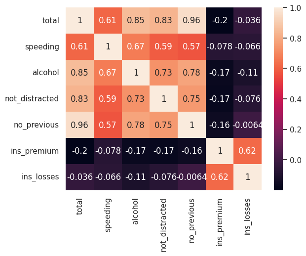

```python
sns.heatmap(corr,annot=True)
```

**Inference - It is used to visualize the correlation matrix corr, with annotation (values) displayed in each cell of the heatmap**

# Line graph

-It represents data points as a series of connected line segments

```python
x = df["total"].values
y = df["alcohol"].values
```

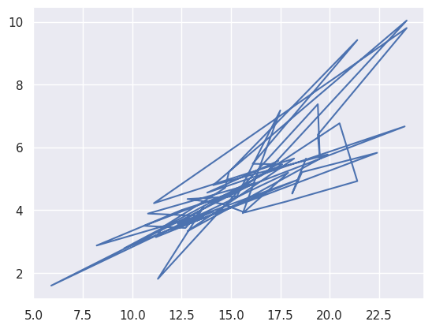

```python
plt.plot(x,y)
```

**Inference - From the plot we can see that Total car crashes are increasing with increasing alcohol value. This is a momentary decrease at some points but overall there is an increase in the "total" variable.**

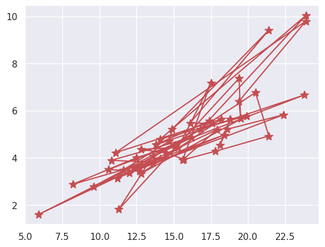

```python
plt.plot(x,y,'r-*',ms=10)
```

**Inference - From the plot we can infer that the r- *(r represents colour,- represents solid line,* represents the marker style) creates a plot with red solid lines connecting data points, and asterisk markers at each data point. It increases readability.**

# Bar graph

```
<BarContainer object of 51 artists>
```

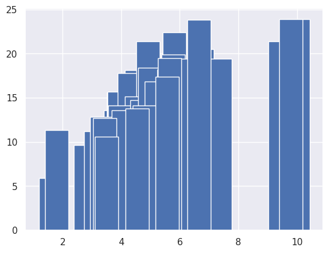

```python
plt.bar(y,x)
```

```
<BarContainer object of 51 artists>
```

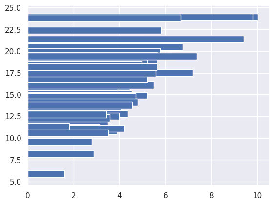

```python
plt.barh(x,y)
```

**Inference - From the plot we can infer that "barh" is used create a horizontal bar plot**

```
<BarContainer object of 51 artists>
```

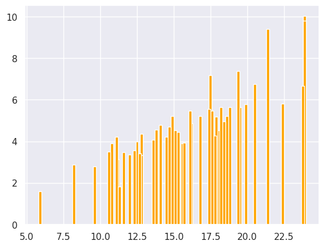

```python
plt.bar(x,y,color="orange",width=0.2)
```

**Inference - From the plot we can infer that we can change the colour and width of the bars using color and width parameters respectively so that it becomes easy to visualize.**

```
<BarContainer object of 51 artists>
```

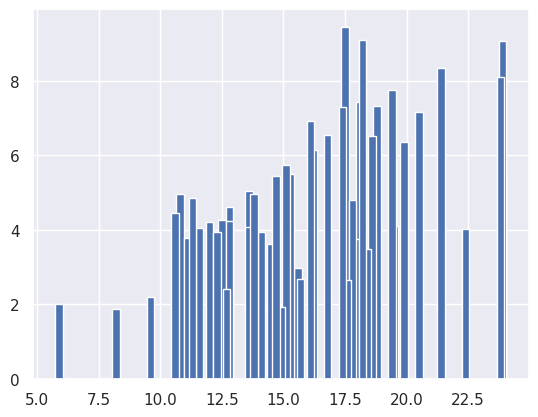

```python
plt.bar(df["total"], df["speeding"], width=0.3)
```

# Histogram

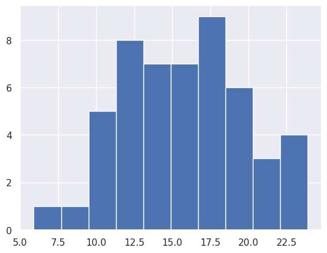

```python
plt.hist(x=df["total"])
```

**Inference - From the plot we can infer that the histogram visually represents how the values in the "total" variable are distributed across different bins or intervals. Each bar in the histogram represents a range of values, and the height of the bar indicates the frequency or count of values within that range.**

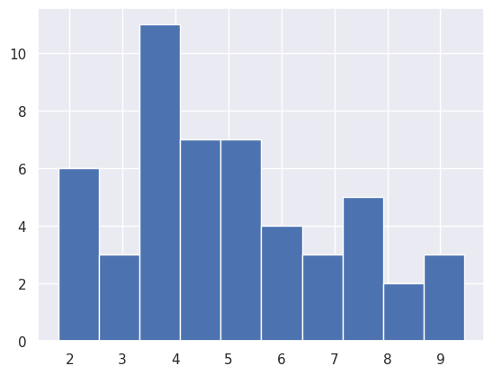

```python
plt.hist(x=df["speeding"])
```

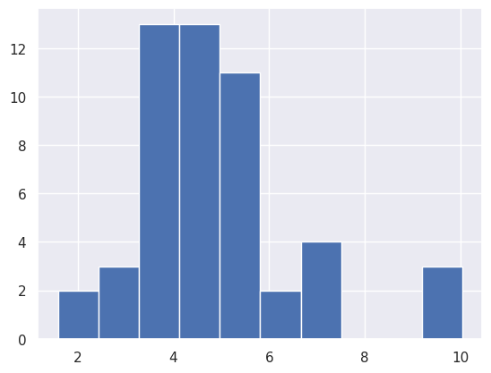

```python
plt.hist(x=df["alcohol"])
```

# Pie chart

```python
print(df.columns)
```

```
Index(['total', 'speeding', 'alcohol', 'not_distracted', 'no_previous',
       'ins_premium', 'ins_losses', 'abbrev'],
      dtype='object')
```

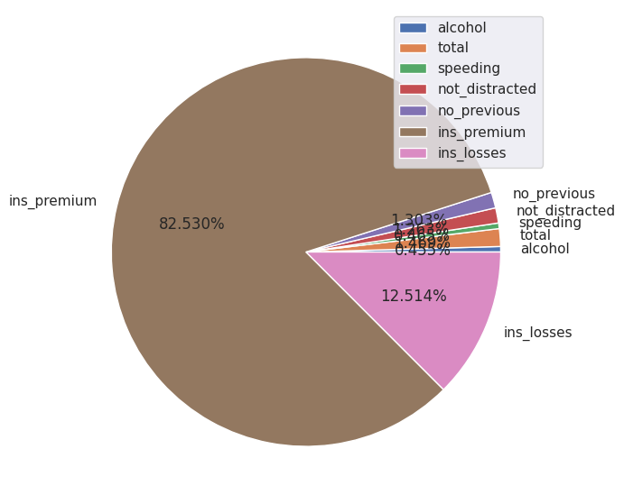

```python
columns_of_interest = ['alcohol', 'total','speeding', 'not_distracted', 'no_previous',
       'ins_premium', 'ins_losses']
data = [df[column].sum() for column in columns_of_interest]
labels = columns_of_interest
plt.figure(figsize=(7,7))
plt.pie(data, labels=labels, autopct='%.3f%%')
plt.legend()
plt.show()
```

**Inference - From the plot we can infer that each sector of the pie chart represents the contribution of one of the selected columns to the total sum of all the columns. The size of each slice is proportional to the sum of values in that column relative to the total sum. The plt.legend() function adds a legend to the pie chart, providing labels for each slice**

# Regression plot

-It is to visualize the linear relationship between the two numerical variables and includes a regression line

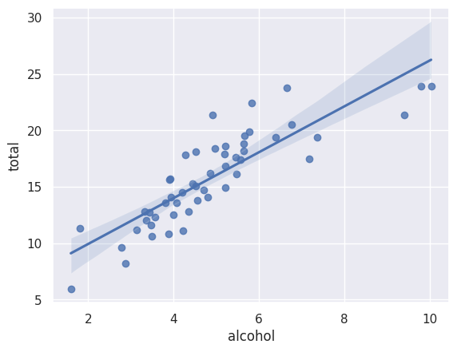

```python
sns.regplot(data=df, x='alcohol', y='total')
```

**Inference - From the plot we can infer that the plot has a regression line (best-fit line) that represents a visual estimate of how changes in "alcohol" are associated with changes in "total".There is a linear relationship between "alcohol" and "total". The slope is positive which indicates that higher values of "alcohol" are associated with higher values of "total."**